# iDEP: Investigating Differentially Expressed Genes

## If this site has contributed to your work, please cite our article:

Ge, S.X., Son, E.W. & Yao, R. iDEP: an integrated web application for differential expression and pathway analysis of RNA-Seq data. BMC Bioinformatics 19, 534 (2018). https://doi.org/10.1186/s12859-018-2486-6

## Summary

Read Counts data were analyzed using iDEP v2.4.3. The data was first filtered to remove reads below 0.5 CPM in at least 1 sample. Then the data was transformed with EdgeR using a pseudocount of 4. Missing values were imputed using geneMedian.

After mapping, there are 42278 unique genes in 39 samples. Of the 31252 genes passed filter, 31189 were converted to Ensembl/STRING gene IDs in our database. The remaining 63 genes were kept in the data using original IDs.

Differential expression analysis was performed using DESeq2 with an FDR cutoff of 0.1 and a minimum fold-change threshold of 2. Standard Wald test was used and independent filtering was disabled.

## Selected Comparison: ANTHO_LESS_&*40_CGY-WT*&_40_CGY

Up-regulated genes: 75

Down-regulated genes: 237

## Top Up-regulated Genes

```r
if (!is.null(params$up_genes_table) && nrow(params$up_genes_table) > 0) {
  kbl(params$up_genes_table, escape = FALSE) %>%
    kable_classic(full_width = FALSE, html_font = "Cambria")
} else {
  print("No up-regulated genes found for this comparison.")
}
```

| Symbol | Ensembl ID | log2 FC | Adj. P-value | Description |
| --- | --- | --- | --- | --- |
| BRA011491 | BRA011491 | 19.054 | 5.79e-03 | AT3G44713 (E=1e-010) \| unknown protein |
| BRA027597 | BRA027597 | 5.855 | 5.73e-02 |  |
| BRA002786 | BRA002786 | 5.352 | 2.18e-02 | AT5G56890 (E=0.0) \| protein kinase family protein |
| BRA016183 | BRA016183 | 4.534 | 6.03e-04 | AT2G07760 (E=3e-015) \| zinc knuckle (CCHC-type) family protein |
| BRA040293 | BRA040293 | 4.306 | 6.03e-04 | AT3G06830 (E=3e-252) \| pectinesterase family protein |
| BRA025198 | BRA025198 | 3.525 | 8.20e-03 | AT3G26290 (E=2e-225) CYP71B26 \| CYP71B26 |
| BRA025281 | BRA025281 | 3.469 | 4.06e-02 | AT4G27710 (E=2e-218) CYP709B3 \| CYP709B3 |
| BRA005469 | BRA005469 | 3.430 | 4.12e-02 | AT2G33830 (E=1e-048) \| dormancy/auxin associated family protein |
| BRA011017 | BRA011017 | 3.106 | 4.83e-03 | AT1G26210 (E=7e-023) \| unknown protein |
| BRA003792 | BRA003792 | 2.946 | 2.53e-02 |  |
| BRA016678 | BRA016678 | 2.932 | 2.93e-02 | AT1G14890 (E=2e-091) \| enzyme inhibitor/ pectinesterase/ pectinesterase inhibitor |
| BRA013465 | BRA013465 | 2.905 | 2.59e-02 | AT4G20440 (E=1e-060) smB \| smB (small nuclear ribonucleoprotein associated protein B) |
| BRA029936 | BRA029936 | 2.818 | 2.09e-02 | AT3G49160 (E=7e-293) \| pyruvate kinase family protein |
| BRA028199 | BRA028199 | 2.760 | 8.39e-02 | AT5G67150 (E=2e-162) \| transferase family protein |
| BRA005423 | BRA005423 | 2.758 | 8.85e-04 | AT2G34420 (E=8e-101) LHB1B2, LHCB1.5 \| LHB1B2 |
| BRA027533 | BRA027533 | 2.722 | 4.83e-03 | AT5G44170 (E=9e-108) \| FUNCTIONS IN: molecular_function unknown |
| BRA031247 | BRA031247 | 2.682 | 2.99e-02 | AT3G21055 (E=3e-019) PSBTN \| PSBTN (photosystem II subunit T) |
| BRA010602 | BRA010602 | 2.659 | 9.55e-03 | AT4G37580 (E=1e-215) HLS1, COP3, UNS2 \| HLS1 (HOOKLESS 1) |
| BRA014873 | BRA014873 | 2.276 | 2.86e-03 |  |
| BRA023957 | BRA023957 | 2.274 | 2.50e-02 | AT4G32290 (E=1e-163) \| unknown protein |
| BRA023676 | BRA023676 | 2.231 | 6.84e-02 | AT5G18470 (E=5e-172) \| curculin-like (mannose-binding) lectin family protein |
| BRA021706 | BRA021706 | 2.224 | 2.83e-03 | AT1G06200 (E=1e-009) \| serine-type peptidase |
| BRA041148 | BRA041148 | 2.094 | 1.85e-05 |  |
| BRA017655 | BRA017655 | 2.075 | 5.05e-02 |  |
| LSU_rRNA_eukarya ENSRNA049460011 | ENSRNA049460011 | 2.049 | 2.80e-02 | Eukaryotic large subunit ribosomal RNA |
| BRA036791 | BRA036791 | 2.049 | 5.79e-03 | AT3G51560 (E=0.0) \| ATP binding / protein binding / transmembrane receptor |
| BRA037400 | BRA037400 | 1.994 | 1.89e-02 | AT1G43245 (E=2e-168) \| FUNCTIONS IN: molecular_function unknown |
| BRA010731 | BRA010731 | 1.975 | 5.79e-03 | AT4G38690 (E=4e-180) \| 1-phosphatidylinositol phosphodiesterase-related |
| BRA015050 | BRA015050 | 1.962 | 1.03e-03 | AT3G24520 (E=1e-113) AT-HSFC1, HSFC1 \| AT-HSFC1 |
| BRA038498 | BRA038498 | 1.915 | 2.10e-03 | AT4G16680 (E=0.0) \| RNA helicase, putative |
| BRA006303 | BRA006303 | 1.912 | 3.11e-02 | AT5G15490 (E=4e-277) \| UDP-glucose 6-dehydrogenase, putative |
| BRA021171 | BRA021171 | 1.902 | 5.04e-03 | AT3G16240 (E=2e-100) DELTA-TIP, TIP2 |
| BRA018810 | BRA018810 | 1.894 | 2.30e-03 | AT5G43730 (E=7e-067) \| disease resistance protein (CC-NBS-LRR class), putative |
| BRA033478 | BRA033478 | 1.886 | 2.13e-02 | AT1G54500 (E=3e-042) \| rubredoxin family protein |
| BRA020161 | BRA020161 | 1.882 | 6.35e-02 | AT5G21950 (E=1e-144) \| hydrolase, alpha/beta fold family protein |
| BRA022735 | BRA022735 | 1.879 | 7.15e-02 | AT5G54630 (E=2e-192) \| zinc finger protein-related |
| BRA036467 | BRA036467 | 1.851 | 5.13e-02 | AT2G20370 (E=1e-278) KAM1, MUR3 \| MUR3 (MURUS 3) |
| BRA014106 | BRA014106 | 1.850 | 2.59e-02 | AT2G47450 (E=7e-149) CAO, CPSRP43 \| CAO (CHAOS) |
| BRA040650 | BRA040650 | 1.843 | 9.89e-02 | AT4G16500 (E=2e-010) \| cysteine protease inhibitor family protein / cystatin family protein |
| BRA014977 | BRA014977 | 1.841 | 7.42e-02 | AT3G23750 (E=3e-223) \| leucine-rich repeat family protein / protein kinase family protein |
| BRA012891 | BRA012891 | 1.810 | 7.55e-03 | AT3G50750 (E=1e-111) \| brassinosteroid signalling positive regulator-related |
| BRA010473 | BRA010473 | 1.753 | 2.46e-02 | AT4G25230 (E=2e-249) RIN2 \| RIN2 (RPM1 INTERACTING PROTEIN 2) |
| BRA028906 | BRA028906 | 1.742 | 6.30e-02 | AT5G01530 (E=2e-142) \| chlorophyll A-B binding protein CP29 (LHCB4) |
| BRA010706 | BRA010706 | 1.737 | 8.84e-02 | AT4G39090 (E=1e-096) RD19, RD19A \| RD19 (RESPONSIVE TO DEHYDRATION 19) |
| BRA012541 | BRA012541 | 1.714 | 3.91e-02 | AT4G19510 (E=7e-253) \| disease resistance protein (TIR-NBS-LRR class), putative |
| BRA002984 | BRA002984 | 1.708 | 4.03e-02 | AT4G27280 (E=6e-051) \| calcium-binding EF hand family protein |
| BRA014140 | BRA014140 | 1.699 | 4.80e-02 | AT1G48480 (E=3e-254) RKL1 \| RKL1 |
| BRA040158 | BRA040158 | 1.693 | 6.74e-02 | AT4G17490 (E=2e-075) ATERF6, ERF-6-6 \| ATERF6 (ETHYLENE RESPONSIVE ELEMENT BINDING FACTOR 6) |
| BRA033933 | BRA033933 | 1.683 | 9.98e-02 | AT1G68460 (E=7e-127) ATIPT1 \| ATIPT1 (isopentenyltransferase 1) |
| BRA007371 | BRA007371 | 1.681 | 6.64e-02 | AT3G57980 (E=2e-108) \| DNA-binding bromodomain-containing protein |

## Top Down-regulated Genes

```r
if (!is.null(params$down_genes_table) && nrow(params$down_genes_table) > 0) {
  kbl(params$down_genes_table, escape = FALSE) %>%
    kable_classic(full_width = FALSE, html_font = "Cambria")
} else {
  print("No down-regulated genes found for this comparison.")
}
```

| Symbol | Ensembl ID | log2 FC | Adj. P-value | Description |
| --- | --- | --- | --- | --- |
| BRA008452 | BRA008452 | -8.011 | 2.09e-02 | AT4G23160 (E=2e-177) \| protein kinase family protein |
| BRA012114 | BRA012114 | -5.938 | 4.83e-03 | AT5G66900 (E=3e-217) \| disease resistance protein (CC-NBS-LRR class), putative |
| BRA017935 | BRA017935 | -5.687 | 6.74e-02 | AT1G21651 (E=0.0) \| protein binding / zinc ion binding |
| BRA015556 | BRA015556 | -5.572 | 5.73e-02 | AT1G07150 (E=1e-051) MAPKKK13 \| MAPKKK13 |
| BRA018419 | BRA018419 | -5.533 | 2.83e-03 | AT1G10880 (E=1e-186) \| unknown protein |
| BRA008847 | BRA008847 | -4.354 | 7.58e-02 | AT5G13210 (E=3e-275) \| CONTAINS InterPro DOMAIN/s: Uncharacterized conserved protein UCP015417, vWA (InterPro:IPR011205), von Willebrand factor, type A (InterPro:IPR002035) |
| BRA029497 | BRA029497 | -4.327 | 6.96e-02 |  |
| BRA016024 | BRA016024 | -4.322 | 6.18e-02 |  |
| BRA024477 | BRA024477 | -4.117 | 8.29e-02 | AT2G18193 (E=7e-238) \| AAA-type ATPase family protein |
| BRA037456 | BRA037456 | -3.978 | 1.34e-02 | AT5G48850 (E=8e-156) ATSDI1 \| ATSDI1 (SULPHUR DEFICIENCY-INDUCED 1) |
| BRA001474 | BRA001474 | -3.976 | 1.38e-03 | AT3G12860 (E=1e-235) \| nucleolar protein Nop56, putative |
| BRA033878 | BRA033878 | -3.917 | 4.06e-02 | AT1G31770 (E=0.0) \| ABC transporter family protein |
| BRA012767 | BRA012767 | -3.803 | 5.89e-03 | AT4G15760 (E=2e-190) MO1 \| MO1 (MONOOXYGENASE 1) |
| BRA036936 | BRA036936 | -3.790 | 8.89e-03 | AT1G43910 (E=2e-221) \| AAA-type ATPase family protein |
| BRA015346 | BRA015346 | -3.732 | 4.20e-03 | AT1G04770 (E=5e-150) \| male sterility MS5 family protein |
| BRA028219 | BRA028219 | -3.636 | 5.79e-03 | AT5G39000 (E=0.0) \| protein kinase family protein |
| BRA015500 | BRA015500 | -3.618 | 2.53e-02 | AT1G06440 (E=2e-200) \| ubiquitin thiolesterase |
| BRA024269 | BRA024269 | -3.573 | 2.49e-02 | AT5G64120 (E=3e-167) \| peroxidase, putative |
| BRA000034 | BRA000034 | -3.562 | 5.96e-03 | AT2G37990 (E=4e-118) \| ribosome biogenesis regulatory protein (RRS1) family protein |
| BRA025937 | BRA025937 | -3.482 | 4.88e-02 | AT1G17930 (E=7e-248) \| unknown protein |
| BRA003558 | BRA003558 | -3.419 | 3.11e-02 | AT1G80240 (E=9e-187) \| unknown protein |
| BRA034795 | BRA034795 | -3.376 | 5.21e-02 | AT3G11964 (E=0.0) \| RNA binding |
| BRA039628 | BRA039628 | -3.368 | 2.28e-02 | AT2G18220 (E=4e-280) \| INVOLVED IN: biological_process unknown |
| BRA017888 | BRA017888 | -3.358 | 9.26e-03 | AT1G60140 (E=0.0) ATTPS10, TPS10 \| ATTPS10 (trehalose phosphate synthase) |
| BRA037463 | BRA037463 | -3.355 | 2.23e-02 | AT5G48740 (E=0.0) \| leucine-rich repeat family protein / protein kinase family protein |
| BRA014494 | BRA014494 | -3.297 | 1.24e-02 | AT3G60360 (E=8e-099) EDA14, UTP11 \| EDA14 (EMBRYO SAC DEVELOPMENT ARREST 14) |
| BRA027673 | BRA027673 | -3.252 | 5.89e-03 | AT1G63980 (E=1e-148) \| D111/G-patch domain-containing protein |
| BRA030202 | BRA030202 | -3.236 | 4.83e-03 | AT2G22795 (E=1e-027) \| unknown protein |
| BRA033023 | BRA033023 | -3.218 | 4.80e-02 | AT3G27700 (E=6e-275) \| RNA recognition motif (RRM)-containing protein |
| BRA017004 | BRA017004 | -3.168 | 1.11e-02 | AT2G40430 (E=3e-069) \| FUNCTIONS IN: molecular_function unknown |
| BRA008555 | BRA008555 | -3.168 | 6.14e-02 | AT4G01730 (E=6e-213) \| zinc ion binding |
| BRA011423 | BRA011423 | -3.158 | 4.26e-02 | AT4G33160 (E=8e-184) \| ubiquitin-protein ligase |
| BRA020209 | BRA020209 | -3.134 | 6.03e-04 | AT5G22650 (E=7e-029) HD2B, HDT02, HDT2, ATHD2B, HDA4, HD2 \| HD2B (HISTONE DEACETYLASE 2B) |
| BRA040374 | BRA040374 | -3.110 | 4.58e-02 | AT3G07360 (E=8e-150) PUB9, ATPUB9 \| PUB9 (PLANT U-BOX 9) |
| BRA031351 | BRA031351 | -3.110 | 6.74e-02 | AT3G22370 (E=2e-166) AOX1A, ATAOX1A \| AOX1A (ALTERNATIVE OXIDASE 1A) |
| BRA029677 | BRA029677 | -3.097 | 7.21e-02 | AT3G07770 (E=3e-154) \| ATP binding |
| BRA000272 | BRA000272 | -3.092 | 4.76e-02 | AT2G42680 (E=1e-070) MBF1A, ATMBF1A \| MBF1A (MULTIPROTEIN BRIDGING FACTOR 1A) |
| BRA000159 | BRA000159 | -3.077 | 2.49e-02 | AT2G40010 (E=8e-149) \| 60S acidic ribosomal protein P0 (RPP0A) |
| BRA022180 | BRA022180 | -3.049 | 9.99e-02 | AT3G16810 (E=1e-261) APUM24 \| APUM24 (Arabidopsis Pumilio 24) |
| BRA029775 | BRA029775 | -3.036 | 4.82e-02 | AT3G09570 (E=2e-205) \| FUNCTIONS IN: molecular_function unknown |
| BRA002166 | BRA002166 | -3.017 | 6.04e-02 | AT5G18525 (E=0.0) \| ATP binding / protein kinase/ protein serine/threonine kinase/ protein tyrosine kinase |
| BRA001502 | BRA001502 | -2.989 | 3.07e-02 | AT3G13360 (E=9e-112) WIP3 \| WIP3 (WPP-domain Interacting Protein 3) |
| BRA002281 | BRA002281 | -2.985 | 6.40e-02 | AT5G20200 (E=6e-218) \| nucleoporin-related |
| BRA004512 | BRA004512 | -2.965 | 9.42e-03 | AT2G46740 (E=2e-304) \| FAD-binding domain-containing protein |
| BRA003583 | BRA003583 | -2.931 | 6.30e-02 | AT1G80750 (E=2e-119) \| 60S ribosomal protein L7 (RPL7A) |
| BRA010337 | BRA010337 | -2.926 | 3.23e-02 | AT4G29100 (E=4e-145) \| ethylene-responsive family protein |
| BRA035128 | BRA035128 | -2.910 | 5.18e-02 | AT1G79590 (E=4e-111) SYP52, ATSYP52 \| SYP52 (SYNTAXIN OF PLANTS 52) |
| BRA014757 | BRA014757 | -2.885 | 6.30e-02 | AT3G55290 (E=2e-135) \| short-chain dehydrogenase/reductase (SDR) family protein |
| BRA001490 | BRA001490 | -2.877 | 5.13e-02 | AT3G13080 (E=0.0) ATMRP3, MRP3 \| ATMRP3 |
| BRA023573 | BRA023573 | -2.871 | 7.15e-02 | AT5G16570 (E=8e-193) GLN1 |

## DEG Heatmap

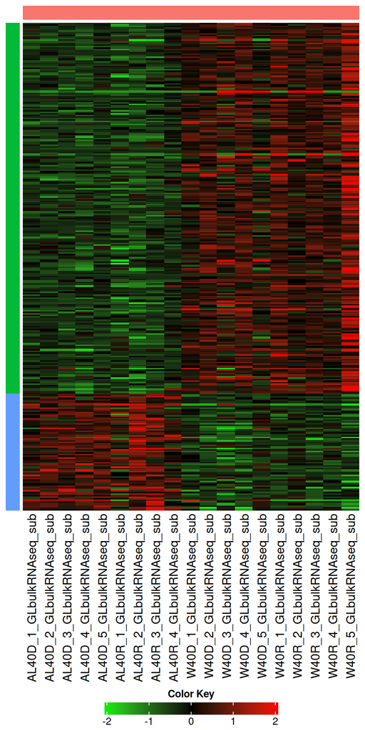

```r
if (!is.null(params$heat_data) && !is.null(params$heat_bar)) {
  heat_colors <- unlist(strsplit(params$heatmap_color_select, "-"))

  deg_heatmap(
    df = params$heat_data,
    bar = params$heat_bar,
    heatmap_color_select = heat_colors,
    cluster_rows = FALSE
  )
}
```

## Volcano Plot

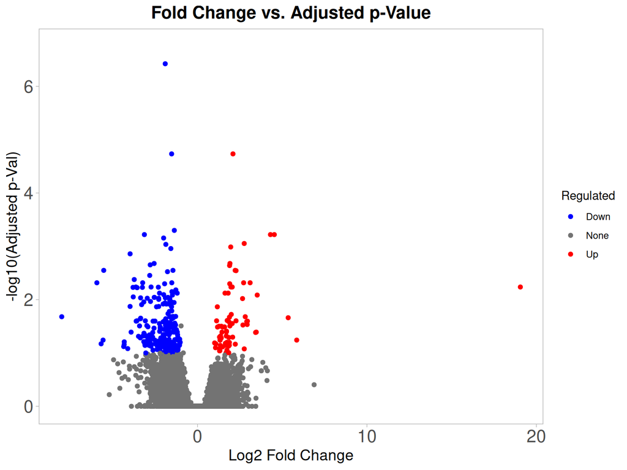

```r
if (!is.null(params$vol_data) && !is.null(params$vol_data$data)) {
  p <- plot_volcano(
    data = params$vol_data$data,
    plot_colors = params$plot_colors,
    anotate_genes = params$gene_labels_volcano
  )
  p <- refine_ggplot2(
    p = p,
    gridline = params$plot_grid_lines,
    ggplot2_theme = params$ggplot2_theme
  )
  print(p)
}
```